# DS152 Introduction to Data Science (2)

Assignment 3: Sampling and Observational Studies

Author

Prof. Niamh Cahill

## Instructions

Answer all questions for continuous assessment. Due: **4pm on Friday, 13th March 2026**.

## Question 1

1. An organization has 500 employees and the HR team decides to conduct a focus group to explore ideas for team building activities. From the list of employee emails they randomly sample 25 to take part in their focus group.

This is an example of

1. Simple random sampling
2. Cluster sampling
3. Stratified sampling
4. Systematic sampling
2. Suppose you are studying rural communities in Ireland. To survey residents of rural areas you pick a random sample of 10 rural communities and focus your efforts on surveying people within those randomly chosen communities.

This is an example of

1. Simple random sampling
2. Cluster sampling
3. Stratified sampling
4. Systematic sampling

## Question 2

Data was collected on 400 individuals to examine the relationship between a person’s income and credit card debt. The variable for credit card debt is called `Balance`. Other variables like credit limit brackets (`limit_bracket`) and marital status (`Married`) are included in the dataset as well. A glimpse of the dataset is shown below.

```r
glimpse(credit_dat)
```

```
Rows: 400
Columns: 12
$ ID            <dbl> 1, 2, 3, 4, 5, 6, 7, 8, 9, 10, 11, 12, 13, 14, 15, 16, 1…
$ Income        <dbl> 14.891, 106.025, 104.593, 148.924, 55.882, 80.180, 20.99…
$ Rating        <dbl> 283, 483, 514, 681, 357, 569, 259, 512, 266, 491, 589, 1…
$ Cards         <dbl> 2, 3, 4, 3, 2, 4, 2, 2, 5, 3, 4, 3, 1, 1, 2, 3, 3, 3, 1,…
$ Age           <dbl> 34, 82, 71, 36, 68, 77, 37, 87, 66, 41, 30, 64, 57, 49, …
$ Education     <dbl> 11, 15, 11, 11, 16, 10, 12, 9, 13, 19, 14, 16, 7, 9, 13,…
$ Gender        <chr> "Male", "Female", "Male", "Female", "Male", "Male", "Fem…
$ Student       <chr> "No", "Yes", "No", "No", "No", "No", "No", "No", "No", "…
$ Married       <chr> "Yes", "Yes", "No", "No", "Yes", "No", "No", "No", "No",…
$ Ethnicity     <chr> "Caucasian", "Asian", "Asian", "Asian", "Caucasian", "Ca…
$ Balance       <dbl> 333, 903, 580, 964, 331, 1151, 203, 872, 279, 1350, 1407…
$ limit_bracket <fct> medium-low, high, high, high, medium-high, high, medium-…
```

1. The plot below shows the relationship between credit card debt (`Balance`) and `Income`. Briefly describe the relationship in your own words.

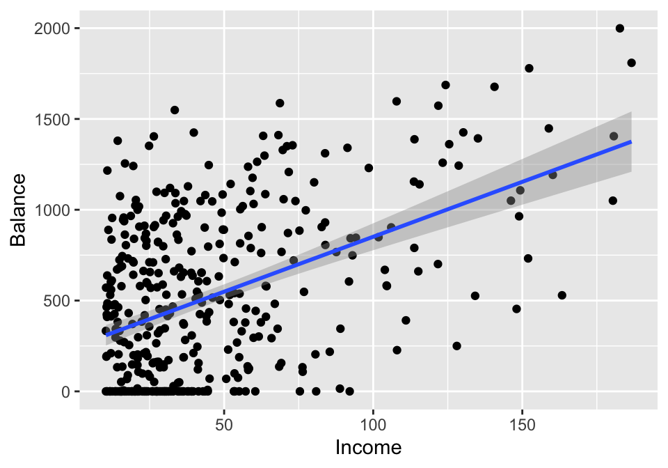

2. Assume you now want to visualise the same information in **(a)** but also include the credit-limit variable (`limit_bracket`). Replace [A], [B], [C], [D], and [E] in the code below to produce the following plot:

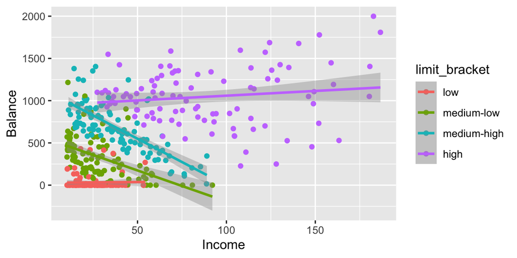

```r
  ggplot(credit_dat, aes(x = [A], y = [B], [C] = limit_bracket)) +
  geom_[D]() +
  geom_smooth(method = [E])
```

[A] =

[B] =

[C] =

[D] =

[E] =

3. From looking at the plot in **(b)**, what impact does including information on credit limits have on how you interpret the relationship between credit-card debt and income? Does Simpson’s Paradox happen here?
4. Assume you now want to calculate the average `Balance` and the average `Income` within each credit-limit bracket. Replace [A], [B], [C] and [D] in the code below to produce the following summary table:

```
# A tibble: 4 × 3
  limit_bracket mean_income mean_balance
  <fct>               <dbl>        <dbl>
1 low                  24.9         33.0
2 medium-low           29.8        323.
3 medium-high          38.3        679.
4 high                 88.0       1045.
```

```r
credit_dat %>%
  group_by([A]) %>%
  [B](mean_income = mean([C]),
      [D] = mean(Balance))
```

A =

B =

C =

D =

5. How does the summary in **(d)** help to explain why the credit limit variable (`limit_bracket`) is a confounding variable when looking at the relationship between credit-card debt and income?